# Strings in R

# Strings

Strings, simply put, are a sequence of characters. The internal representation of these character are subject to what is known as ‘encoding’ – one of the common encoding systems used is the American Standard Code for Information Interchange (ASCII).

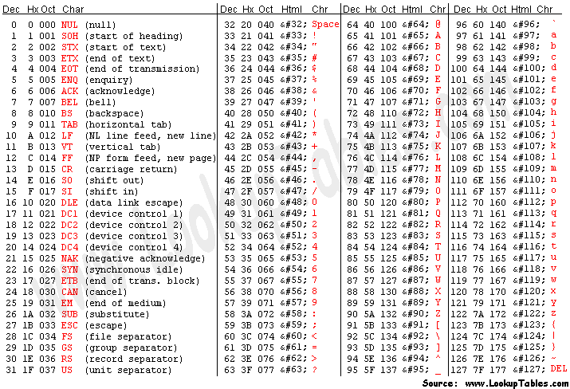

However, the encoding for the greater majority of operations with text data defaults to UTF-8 (a UNICODE standard) as this allows the introduction of characters that don’t exist in the English lexicon.

In R, the word ‘string’ usually refers character vector of length 1.

## Construction

Making strings in R is simpe and straightforward. Recalling that we have string literals, which are constants and identifiable by the R interpreter by quoting.All the operations that lead to the formation of the character sequence are carried out under the hood. However, to access low-level operations, one could use raw vectors (vectors whose elements are individual bytes)

```r
greet <- "Hello"
charToRaw(greet)
```

```
## [1] 48 65 6c 6c 6f
```

The output of the above code can be compared with the ASCII lookup table. Note that the values are in hexadecimal (base 16).

For day-to-day data analysis, there is no need to worry about low-level string representations and in English-speaking locales, there is rarely the need to worry about encoding. The locale is normally set during installation, but can be modified with the appropriate functions during an R session. To check the current locale,

```r
Sys.getlocale()
```

```
## [1] "LC_COLLATE=English_United Kingdom.1252;LC_CTYPE=English_United Kingdom.1252;LC_MONETARY=English_United Kingdom.1252;LC_NUMERIC=C;LC_TIME=English_United Kingdom.1252"
```

### Special characters

There are a few special characters that are used in R that are usually denoted with ‘escapes’. Escaping is a concept where a character’s meaning is no longer as-is, but altered by an adjunct character - in most modern languages this is the backslash (`\`) character. Escaping allows us to nest quotation marks when writing strings.

```r
cat("We use quotation marks create a \"string\".")
```

```
## We use quotation marks create a "string".
```

## Capacity

We can check the size of a string using the `nchar` function

```r
nchar(greet)
```

```
## [1] 5
```

And it is equally vectorized

```r
greetings <- c(greet, "Hi", "Hey", "Whassuuup")
nchar(greetings)
```

```
## [1] 5 2 3 9
```

### Some corner cases

The function `character()` creates a character vector. The first corner case is a character vector with no length and no quoted portions.

```r
character()
```

```
## character(0)
```

This simply means there is nothing there. However, using this function is sometimes useful when we can to make sure a function argument receives only character vectors as input.

```r
is.character(character())   # TRUE
```

```
## [1] TRUE
```

```r
length(character())
```

```
## [1] 0
```

```r
myfun <- function(x = character()) {
  stopifnot(is.character(x))
  "The input is a character vector"
}

myfun()
```

```
## [1] "The input is a character vector"
```

```r
myfun(42)
```

```
## Error in myfun(42): is.character(x) is not TRUE
```

```r
myfun("What am I?")
```

```
## [1] "The input is a character vector"
```

# Operations

## Concatenation

In R we can join 2 or more strings together using the `paste` and `paste0` functions (their defaults differ by how they handle spaces).

```r
paste("Hello", "World")
```

```
## [1] "Hello World"
```

```r
paste("The", "quick", "brown", "fox", "jumps")
```

```
## [1] "The quick brown fox jumps"
```

```r
paste0("CV.", "docx")
```

```
## [1] "CV.docx"
```

and they follow the rules of vectorization and recycling:

```r
oneTofive <- 1:5
AtoE <- LETTERS[oneTofive]

paste(AtoE, oneTofive)
```

```
## [1] "A 1" "B 2" "C 3" "D 4" "E 5"
```

```r
paste0(AtoE, oneTofive)
```

```
## [1] "A1" "B2" "C3" "D4" "E5"
```

```r
(qno <- paste0("(Ques. ", oneTofive, ") =>"))
```

```
## [1] "(Ques. 1) =>" "(Ques. 2) =>" "(Ques. 3) =>" "(Ques. 4) =>" "(Ques. 5) =>"
```

## Replacement

Say we already have a string (or a collection of strings as a character vector with length > 1), there are ways that R allows us to make replace characters within a string For instance, to replace characters in a string, we can use the function `chartr`.

```r
chartr(old = "_", new = "-", "holiday_inn")
```

```
## [1] "holiday-inn"
```

```r
chartr("pp", "ff", "wapple")
```

```
## [1] "waffle"
```

It also does replacement along the length of a vector:

```r
chartr("=", "-", qno)
```

```
## [1] "(Ques. 1) ->" "(Ques. 2) ->" "(Ques. 3) ->" "(Ques. 4) ->" "(Ques. 5) ->"
```

## Checks

There are functions for checking prefixes and suffixes of strings - `startsWith` and `endsWith`.

```r
song <- "Title: \"Blame It On The Rain\""
startsWith(x = song, "Title")
```

```
## [1] TRUE
```

```r
vars <- names(iris)
startsWith(x = vars, prefix = "Petal")
```

```
## [1] FALSE FALSE  TRUE  TRUE FALSE
```

## Substrings

A section of a string can be extracted using the `substr` and `substring` functions. The arguments are the string, the starting position and the ending as integers

```r
substr(song, 1, 5)
```

```
## [1] "Title"
```

```r
substr(song, 9, 13)
```

```
## [1] "Blame"
```

We can also use code to identify the starting and ending points, but that’s the job of regular expressions (discussed below).

The assignment version of these functions can also be used to make text replacements. Note that this modifies the string in place i.e. we don’t need to reassign its name.

```r
substr(song, 1, 5) <- "TITLE"
song
```

```
## [1] "TITLE: \"Blame It On The Rain\""
```

## Splitting

A string can be split into many pieces based on one (or a sequence) of its characters. Let say, for example we have a portion of text that has several sentences. We can create a collection of all the sentences, since a properly written sentence terminates with a period (`.`).

```r
txt <- "Today is Friday. Some say \"Thank God it's Friday\", and they may have good reasons for saying so. However, there are those who actually enjoy their work so much that they rue weekends."

strsplit(x = txt, split = '. ', fixed = TRUE)
```

```
## [[1]]
## [1] "Today is Friday"
## [2] "Some say \"Thank God it's Friday\", and they may have good reasons for saying so"
## [3] "However, there are those who actually enjoy their work so much that they rue weekends."
```

We have used the `fixed` argument to avoid the interpretation of `split` as a regular expression.

# Regular expressions

In the preceding section, we had occasion to mention **regular expressions**. So, what are they? Regular expressions are a set of characters that are used to denote patterns in strings and these can be used to identify and modify them.

## How regex works

Let’s look at the word “apple”. It has 5 letters “a”, “p”, “p”, “l” and “e”. However it has only 4 patterns i.e. **kinds of characters** – `a`, `p`, `l` and `e` since the letter “p” occurs twice. Thus, we use the pattern to ask a question like “Does the letter ‘p’ exist in the word ‘apple’”? The answer of course is “Yes”.

One of the key functions that uses regex in R is `grep`; by default it applies a pattern to a character vector and returns the index for the element that matches that pattern. So, using R code to ask the question above, with

```r
grep(pattern = 'p', x = 'apple')
```

```
## [1] 1
```

we find that the vector `x` matches the pattern “p” at position `1L`. For clarity, we will add more elements to the input vector.

```r
chr <- c("triplet", "home", "turf", "holy", "apple", "clothes")
grep('p', chr)
```

```
## [1] 1 5
```

The result says that the vector `chr` has 2 elements that contain the letter “p” at positions `1` and `5`.

`grep` has other arguments such as `value` and `ignore.case` to give additional capabilities.

```r
grep('p', chr, value = TRUE)
```

```
## [1] "triplet" "apple"
```

So, instead of the index, it is often more useful to know what exactly matches the pattern.

Regular expressions are case-sensitive, so `grep` gives us the option of overriding this

```r
# Match with a capital 'P'
grep('P', chr)
```

```
## integer(0)
```

```r
grep('P', chr, ignore.case = TRUE)
```

```
## [1] 1 5
```

Then we have the variant of `grepl` that just checks and returns a logical result – also extremely useful during analyses.

```r
grepl('p', chr)
```

```
## [1]  TRUE FALSE FALSE FALSE  TRUE FALSE
```

### Metacharacters

We have already seen that all regular characters i.e. letters and digits (in ASCII mode) match themselves. In addition to these we have the metacharacters `. \ | ( ) [ { ^ $ * + ?` that singly or in combination have can have various meanings depending on how they are used.

#### Anchors

The characters `^` and `$` are used to represent the beginning or end of a string, respectively. Thus, using our vector `chr`we can check for all the strings that contain a ‘t’ as follows

```r
grep('t', chr, value = T)
```

```
## [1] "triplet" "turf"    "clothes"
```

but if we want to check only strings that **start** with ‘t’, we will use the `^` character as our anchor

```r
grep("^t", chr, value = T)
```

```
## [1] "triplet" "turf"
```

and if we add more characters, we can fine-tune the search

```r
grep('^tu', chr, value = T)
```

```
## [1] "turf"
```

The strings “triple” and “turf” both have ‘t’ and ‘r’ in them, but their order of use differs and regular expressions are strict when it comes to order

```r
grep('^tr', chr, value = TRUE)
```

```
## [1] "triplet"
```

The regex `^tr` is interpreted as “*a string that starts with a ‘t’ followed by an ‘r’, both of which are lower-case letters*”.

Use of the termination anchor `$` is similar

```r
grep("e", chr, value = TRUE)
```

```
## [1] "triplet" "home"    "apple"   "clothes"
```

```r
grep("e$", chr, value = TRUE)
```

```
## [1] "home"  "apple"
```

```r
grep("me$", chr, value = TRUE)
```

```
## [1] "home"
```

#### Quantifiers

The metacharacters `* ? + {n} {n, } {n,m}` are used to state how many times a character is to be matched in sequence. This is how they are interpreted for any character `X`:

| Meta | Matches |
| --- | --- |
| `+` | One or more times |
| `*` | Zero or more times |
| `?` | At most once i.e. it is optional |
| `{n}` | Exactly `n` times |
| `{n,}` | At least `n` times |
| `{n,m}` | Between `n` and `m` times (inclusively) |